# Lecture #8: Second Derivative, Differentiable Functions & Limits Revisited

MATH 145 – Calculus I

Torin Quinlivan

tquinlivan@knox.edu

Knox College

October 2, 2025

## The Second Derivative

The derivative of $f$, $f'$, is just another function, related to $f$.

What if we took the derivative of the derivative function?

We get what is called the second derivative.

($f'(x)$ is called the first derivative.)

## The Second Derivative

The second derivative, $f''(x)$, is defined by the limit definition of the derivative of the first derivative. That is,
$$f''(x) = \lim\limits_{h \to 0} \frac{f'(x+h) - f'(x)}{h}$$

$f''(x)$ is sometimes written as $\dfrac{d^2}{dx^2} f(x)$.

## The $n^{\textrm{th}}$ Derivative

We can keep this process going, taking the derivative of the second derivative to get the third derivative, $f'''(x)$, take the derivative of that to get the fourth derivative, $f^{(4)}(x)$, and so on and so on.

The $n^{th}$ derivative of $f$ is denoted as $f^{(n)}(x)$.

## Example: The Second Derivative

**Example:** Find the second derivative of $f(x) = 4x - 9$.

**Example:** Find the second derivative of $f(x) = 3x^2 + 5x + 7$.

**Example:** Let $g(x) = \dfrac{1}{x}$. Find $g''(4)$.

## The Second Derivative, Graphically

**Example:** Sketch the graph of $q''(x)$ if $q(x)$ has the graph below.

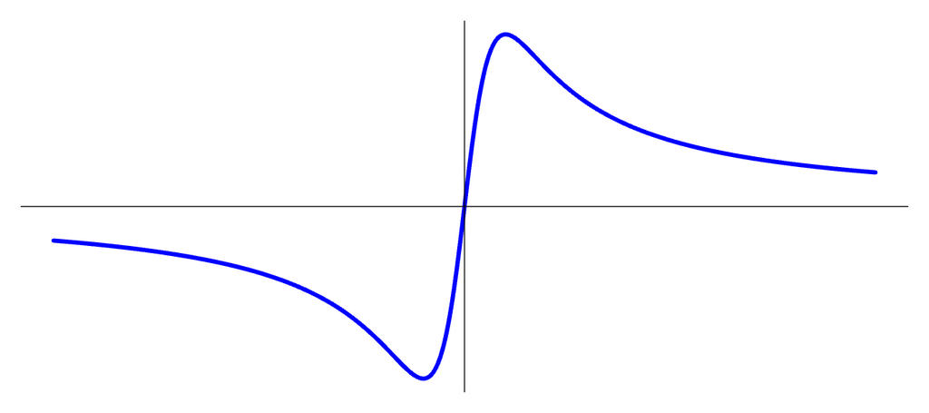

## Concavity of a Function

There is more to describing the shape of a graph other than just whether it is increasing or decreasing.

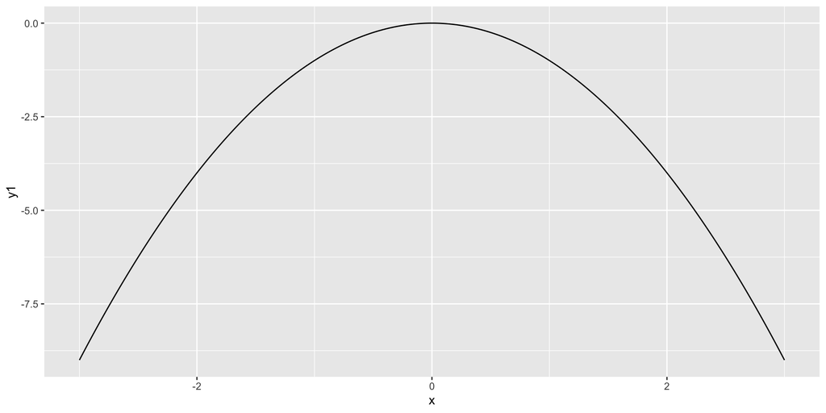

Figure 1: $a < 0$

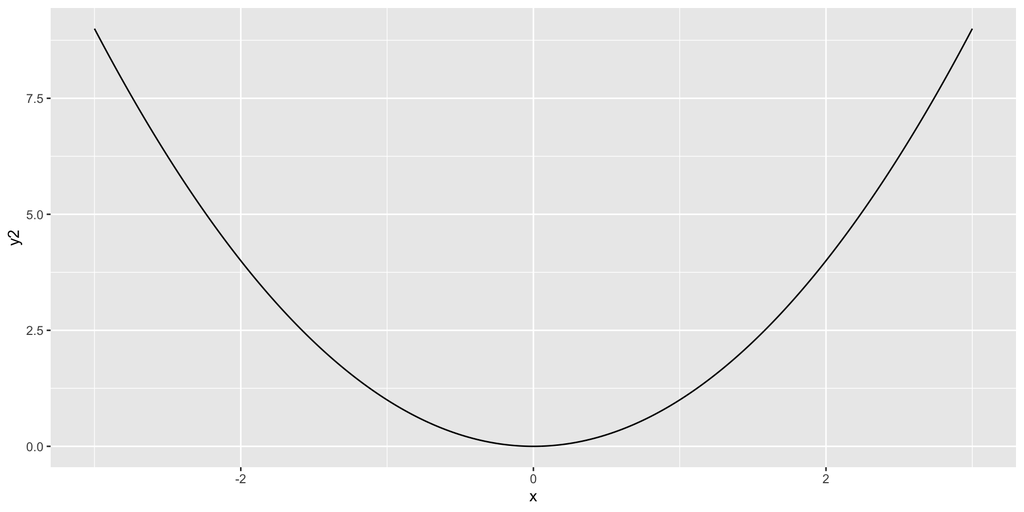

Figure 2: $a > 0$

## Concavity of a Function

Let $f$ be a differentiable function on an interval $(a, b)$. Then $f$ is concave up on $(a, b)$ if and only if $f'$ is increasing on $(a, b)$.

Let $f$ be a differentiable function on an interval $(a, b)$. Then $f$ is concave down on $(a, b)$ if and only if $f'$ is decreasing on $(a, b)$.

## Concavity of a Function

Recall that:

Let $f$ be a function that is differentiable on an interval $(a, b)$. If $f'(x) > 0$ for every $x$ such that $a < x < b$, then $f$ is increasing on $(a, b)$.

Let $f$ be a function that is differentiable on an interval $(a, b)$. If $f'(x) < 0$ for every $x$ such that $a < x < b$, then $f$ is decreasing on $(a, b)$.

## Concavity of a Function

Combining these definition gives us that:

- $f''(x)$ is positive on $(a, b)$ if and only if $f(x)$ is concave up on $(a, b)$.
- $f''(x)$ is negative on $(a, b)$ if and only if $f(x)$ is concave down on $(a, b)$.

## Relative Extrema and Inflection Points

The point where a graph $f$ switches from increasing to decreasing or vice versa is called a relative extreme.

If $f$ goes from increasing to decreasing, the relative extreme is called a maximum.

If $f$ goes from decreasing to increasing, the relative extreme is called a minimum.

An inflection point is a point of a graph $f$ where concavity changes.

## Recall the Limit of a Function at a Point

Given a function $f$, a fixed input $x=a$, and a real number $L$, we say that $f$ has limit $L$ as $x$ approaches $a$, and write
$$\lim_{x \to a} f(x) = L$$

provided that we can make $f(x)$ as close to $L$ as we like by taking $x$ sufficiently close (but not equal) to $a$. If we cannot make $f(x)$ as close to a single value as we would like as $x$ approaches $a$, then we say that $f$ does not have a limit as $x$ approaches $a$.

## Recall Left-Hand Limits

We say that $f$ has limit $L_1$ as $x$ approached $a$ from the left and write

$$\lim_{x \to a^-} f(x) = L_1$$

provided that we can make the value of $f(x)$ as close to $L_1$ as we like by taking $x$ sufficiently close to $a$, while always having $x < a$. We call $L_1$ the left-hand limit of $f$ as $x$ approaches $a$.

## Recall Right-Hand Limits

We say that $f$ has limit $L_2$ as $x$ approached $a$ from the right and write

$$\lim_{x \to a^+} f(x) = L_2$$

provided that we can make the value of $f(x)$ as close to $L_2$ as we like by taking $x$ sufficiently close to $a$, while always having $x > a$. We call $L_1$ the right-hand limit of $f$ as $x$ approaches $a$.

## Recall Left-Hand and Right-Hand Limits

A function $f$ has limit $L$ as $x \to a$ if and only if
$$\lim_{x \to a^-} f(x) = L = \lim_{x \to a^+} f(x)$$

## Non-Differentiable Functions

**Example:** Show that the derivative of $f(x) = \vert x \vert$ does not exist at $x = 0$.

The derivative of $f(x)$ will not exists at a point $x = a$ if there is a “cusp”, or corner or sharp turn, on the graph there.

## Continuity

A function $f$ is continuous at $x=a$ provided that:

- $f$ has a limit as $x \to a$,
- $f$ is defined at $x=a$, and
- $\lim\limits_{x \to a} f(x) = f(a)$.

## Differentiability

We say that a function $f$ is differentiable at $x = a$ if it has a derivative at $x = a$.

- If $f$ is differentiable at $x = a$, the $f$ is continuous at $x = a$.
- Equivalently, if $f$ fails to be continuous at $x = a$, the $f$ will not be differentiable at $x = a$.
- A function can be continuous at a point, but not be differentiable there. In particular, a function $f$ is not differentiable at $x = a$ if the graph has a sharp corner (or *cusp*) at the point $(a, f(a))$.
- If $f$ is differentiable at $x = a$, the $f$ is *locally linear* at $x = a$. That is, when a function is differentiable, it looks linear when viewed up close because it resembles its tangent line there.

## Example: Continuity and Differentiability

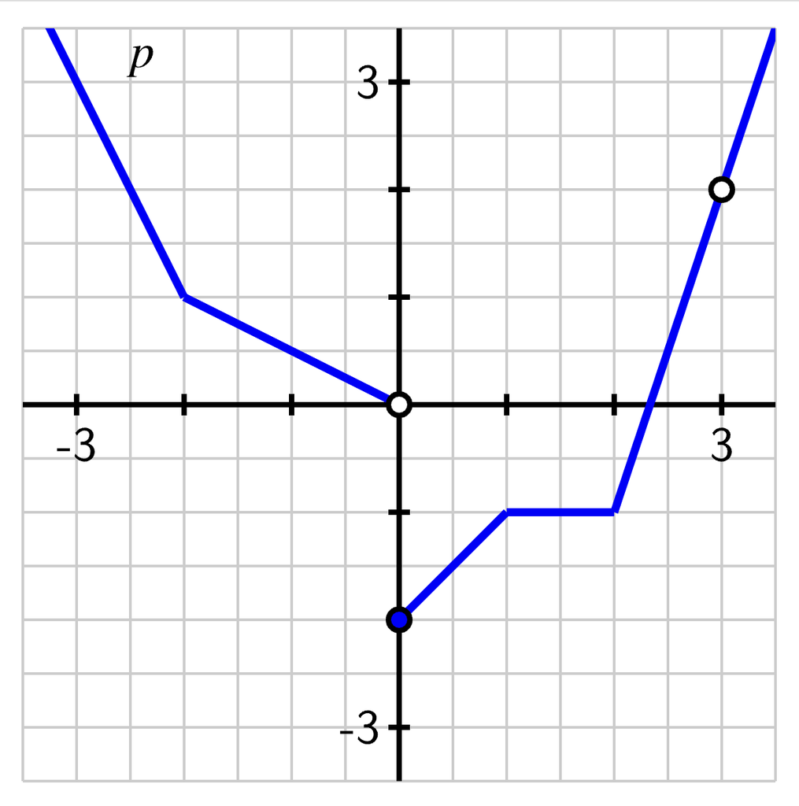

1. Where is this function not continuous?
2. Where is this function not differentiable?

## Local Linearization

If $f(x)$ is differentiable at $x = a$, the local linearization (or tangent line approximation) to $f(x)$ near $x = a$ is the function
$$y = L(x) \approx f(a) + f'(a)(x - a)$$

If $f(x)$ is differentiable at $x = a$, you can approximate it by its tangent line.

## Example: Local Linearization

**Example:** Let $f(x) = x^2$.

Find $f(2.3)$, and then estimate it with the local linearization of $f$ using $x = 2$.